# Modelando casos raros com oversampling, undersampling e synthetic sampling

## Orientacoes para execucao

Todos os pacotes utilizados neste script devem ser/estar instalados no seu ambiente de desenvolvimento. Para instalar um pacote use o comando install.packages(“nome_do_pacote”)

Carrega as bibliotecas

```r
library(ROSE)
library(DMwR)
library(rpart)
```

Carrega os dados que serão usados no tutorial.

```r
data(hacide)
```

Trabalharemos com dois datasets do pacote ROSE: hacide.train e hacide.test.

A seguir a distribuição da variavel target.

```r
table(hacide.train$cls)
```

```
##
##   0   1
## 980  20
```

```r
prop.table(table(hacide.train$cls))
```

```
##
##    0    1
## 0.98 0.02
```

Agora vamos treinar um modelo de árvore de decisao para usar como referência.

```r
treeimb <- rpart(cls ~ ., data = hacide.train)
pred.treeimb <- predict(treeimb, newdata = hacide.test)
```

Verifica o resultado do modelo.

```r
accuracy.meas(hacide.test$cls, pred.treeimb[,2])
```

```
##
## Call:
## accuracy.meas(response = hacide.test$cls, predicted = pred.treeimb[,
##     2])
##
## Examples are labelled as positive when predicted is greater than 0.5
##
## precision: 1.000
## recall: 0.200
## F: 0.167
```

```r
roc.curve(hacide.test$cls, pred.treeimb[,2], plotit = F)
```

```
## Area under the curve (AUC): 0.600
```

Vamos criar um dataset aplicando oversampling. Note que usamos N = 1960 porque criaremos um dataset balanceado com 50% para cada tipo de classe. Como temos 980 casos como target = 0, todos eles serao utilizados sem repetição. Ja nos casos onde target = 1, duplicaremos as observações até alcancar a quantidade de registros desejada.

```r
data_balanced_over <- ovun.sample(cls ~ ., data = hacide.train, method = "over", N = 1960)$data
table(data_balanced_over$cls)
```

```
##
##   0   1
## 980 980
```

Da mesma forma criaremos o dataset aplicando undersampling

```r
data_balanced_under <- ovun.sample(cls ~ ., data = hacide.train, method = "under", N = 40, seed = 1)$data
table(data_balanced_under$cls)
```

```
##
##  0  1
## 20 20
```

Ainda temos a opção de aplicar as duas técnicas ao mesmo tempo, como no comando abaixo. O parametro “p” refere-se a probabilidade de casos positivos na nova amostra de dados.

```r
data_balanced_both <- ovun.sample(cls ~ ., data = hacide.train, method = "both", p=0.5, N=1000, seed = 1)$data
table(data_balanced_both$cls)
```

```
##
##   0   1
## 520 480
```

As técnicas que usamos até agora possuem alguns pontos de atenção: * No caso do undersampling, perdemos informações de uma das classes (neste caso, classe = 0) * No caso do oversampling, geramos um volume considerável de observações repetidas de uma das classes (neste caso, classe = 1) Para evitar estes problemas, podemos gerar dados de forma sintética.

```r
data.rose <- ROSE(cls ~ ., data = hacide.train, seed = 1)$data
table(data.rose$cls)
```

```
##
##   0   1
## 520 480
```

```r
data.smote <- SMOTE(cls ~ ., hacide.train, perc.over = 100, perc.under=200)
table(data.smote$cls)
```

```
##
##  0  1
## 40 40
```

Agora vamos treinar um modelo para cada dataset de treino.

```r
tree.rose <- rpart(cls ~ ., data = data.rose)
tree.smote <- rpart(cls ~ ., data = data.smote)
tree.over <- rpart(cls ~ ., data = data_balanced_over)
tree.under <- rpart(cls ~ ., data = data_balanced_under)
tree.both <- rpart(cls ~ ., data = data_balanced_both)
```

Finalmente executar os modelos em dados de teste.

```r
pred.tree.rose <- predict(tree.rose, newdata = hacide.test)
pred.tree.smote <- predict(tree.smote, newdata = hacide.test)
pred.tree.over <- predict(tree.over, newdata = hacide.test)
pred.tree.under <- predict(tree.under, newdata = hacide.test)
pred.tree.both <- predict(tree.both, newdata = hacide.test)
```

Hora de verificar os resultados de cada um. Começando pelo syntatic sampling gerado pelo pacote ROSE.

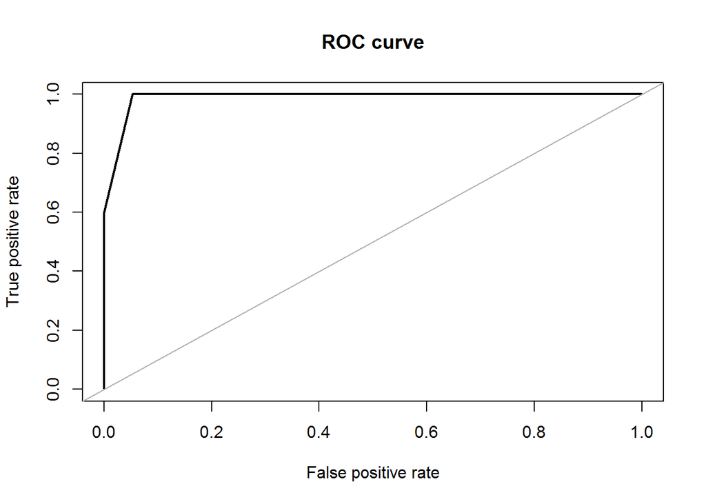

```
## Area under the curve (AUC): 0.989
```

```r
roc.curve(hacide.test$cls, pred.tree.rose[,2])
```

```r
accuracy.meas(hacide.test$cls, pred.tree.rose[,2])
```

```
##
## Call:
## accuracy.meas(response = hacide.test$cls, predicted = pred.tree.rose[,
##     2])
##
## Examples are labelled as positive when predicted is greater than 0.5
##
## precision: 0.278
## recall: 1.000
## F: 0.217
```

Syntatic sampling gerado com SMOTE.

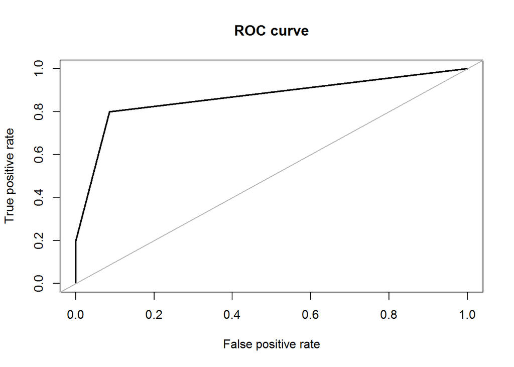

```
## Area under the curve (AUC): 0.866
```

```r
roc.curve(hacide.test$cls, pred.tree.smote[,2])
```

```r
accuracy.meas(hacide.test$cls, pred.tree.smote[,2])
```

```
##
## Call:
## accuracy.meas(response = hacide.test$cls, predicted = pred.tree.smote[,
##     2])
##
## Examples are labelled as positive when predicted is greater than 0.5
##
## precision: 0.160
## recall: 0.800
## F: 0.133
```

Oversampling.

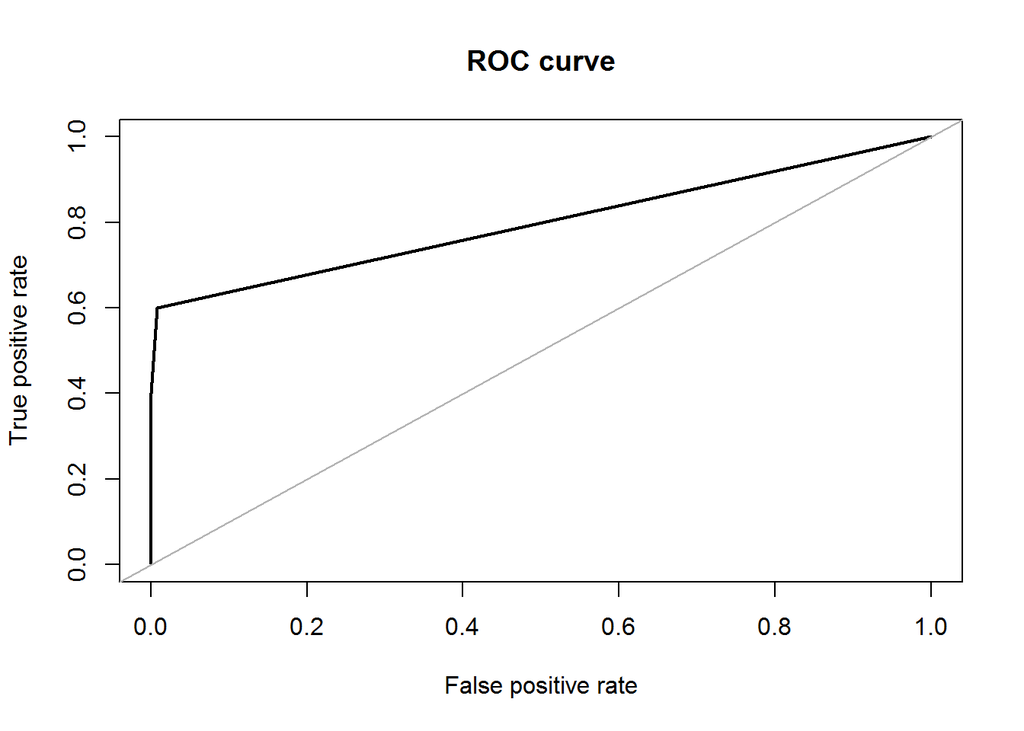

```
## Area under the curve (AUC): 0.798
```

```r
roc.curve(hacide.test$cls, pred.tree.over[,2])
```

```r
accuracy.meas(hacide.test$cls, pred.tree.over[,2])
```

```
##
## Call:
## accuracy.meas(response = hacide.test$cls, predicted = pred.tree.over[,
##     2])
##
## Examples are labelled as positive when predicted is greater than 0.5
##
## precision: 0.600
## recall: 0.600
## F: 0.300
```

Undersampling.

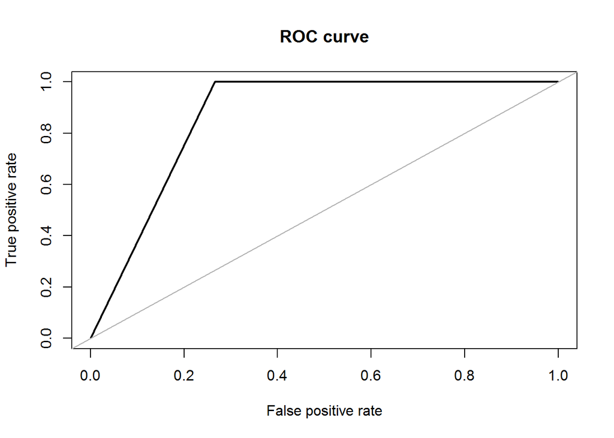

```
## Area under the curve (AUC): 0.867
```

```r
roc.curve(hacide.test$cls, pred.tree.under[,2])
```

```r
accuracy.meas(hacide.test$cls, pred.tree.under[,2])
```

```
##
## Call:
## accuracy.meas(response = hacide.test$cls, predicted = pred.tree.under[,
##     2])
##
## Examples are labelled as positive when predicted is greater than 0.5
##
## precision: 0.071
## recall: 1.000
## F: 0.067
```

Ambos.

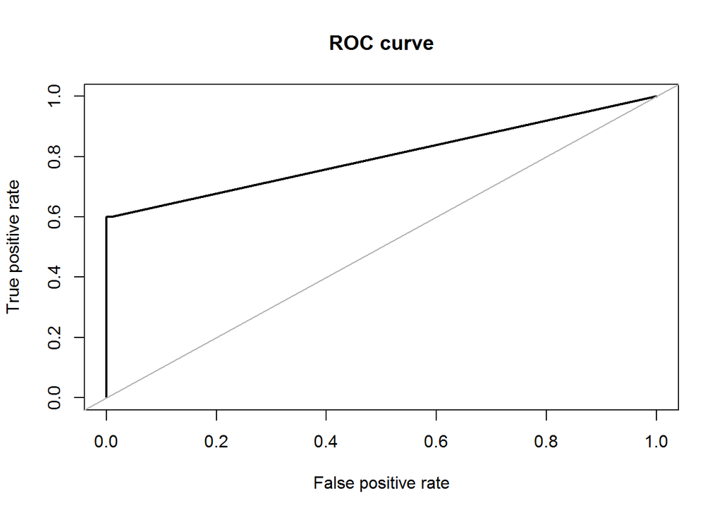

```
## Area under the curve (AUC): 0.798
```

```r
roc.curve(hacide.test$cls, pred.tree.both[,2])
```

```r
accuracy.meas(hacide.test$cls, pred.tree.rose[,2])
```

```
##
## Call:
## accuracy.meas(response = hacide.test$cls, predicted = pred.tree.rose[,
##     2])
##
## Examples are labelled as positive when predicted is greater than 0.5
##
## precision: 0.278
## recall: 1.000
## F: 0.217
```

```r
ROSE.holdout <- ROSE.eval(cls ~ ., data = hacide.train, learner = rpart, method.assess = "holdout", extr.pred = function(obj)obj[,2], seed = 1)
ROSE.holdout
```

```
##
## Call:
## ROSE.eval(formula = cls ~ ., data = hacide.train, learner = rpart,
##     extr.pred = function(obj) obj[, 2], method.assess = "holdout",
##     seed = 1)
##
## Holdout estimate of auc: 0.985
```

Referência: https://www.analyticsvidhya.com